# 线性回归预测汽车销量-Copy1

目标:用线性回归预测汽车销量

```python
import numpy as np
import pandas as pd
import matplotlib.pyplot as plt
import seaborn as sns
import statsmodels.api as sm
import warnings
warnings.filterwarnings('ignore')
plt.rcParams['font.sans-serif']=['simhei']
```

```python
data = pd.read_csv('汽车模拟数据.csv')
data
```

|  | 月份 | 平均油价（元/升） | 政策补贴（元/辆） | 是否有促销活动（0/1） | 季节 | 销量（辆） |
| --- | --- | --- | --- | --- | --- | --- |
| 0 | 2015-01 | 6.73 | 4310 | 1 | 4（冬季） | 1234 |
| 1 | 2015-02 | 6.81 | 4152 | 1 | 4（冬季） | 1289 |
| 2 | 2015-03 | 7.05 | 4589 | 0 | 1（春季） | 1056 |
| 3 | 2015-04 | 6.98 | 4421 | 1 | 1（春季） | 1320 |
| 4 | 2015-05 | 7.12 | 4608 | 0 | 1（春季） | 1109 |
| ... | ... | ... | ... | ... | ... | ... |
| 115 | 2024-08 | 7.75 | 4820 | 0 | 2（夏季） | 2156 |
| 116 | 2024-09 | 7.68 | 5500 | 1 | 3（秋季） | 2476 |
| 117 | 2024-10 | 7.60 | 7300 | 1 | 3（秋季） | 2923 |
| 118 | 2024-11 | 7.52 | 7400 | 1 | 3（秋季） | 2995 |
| 119 | 2024-12 | 7.42 | 7550 | 1 | 4（冬季） | 3160 |

120 rows × 6 columns

```python
data.info()
```

```
<class 'pandas.core.frame.DataFrame'>
RangeIndex: 120 entries, 0 to 119
Data columns (total 6 columns):
 #   Column        Non-Null Count  Dtype
---  ------        --------------  -----
 0   月份            120 non-null    object
 1   平均油价（元/升）     120 non-null    float64
 2   政策补贴（元/辆）     120 non-null    int64
 3   是否有促销活动（0/1）  120 non-null    int64
 4   季节            120 non-null    object
 5   销量（辆）         120 non-null    int64
dtypes: float64(1), int64(3), object(2)
memory usage: 5.8+ KB
```

```python
data.rename(columns={"季节（1-4）":"季节"},inplace=True)
data['季节'] = data['季节'].astype(str)
data['季节'] = data['季节'].str.split('（').str[1].str.split('）').str[0]
data
```

|  | 月份 | 平均油价（元/升） | 政策补贴（元/辆） | 是否有促销活动（0/1） | 季节 | 销量（辆） |
| --- | --- | --- | --- | --- | --- | --- |
| 0 | 2015-01 | 6.73 | 4310 | 1 | 冬季 | 1234 |
| 1 | 2015-02 | 6.81 | 4152 | 1 | 冬季 | 1289 |
| 2 | 2015-03 | 7.05 | 4589 | 0 | 春季 | 1056 |
| 3 | 2015-04 | 6.98 | 4421 | 1 | 春季 | 1320 |
| 4 | 2015-05 | 7.12 | 4608 | 0 | 春季 | 1109 |
| ... | ... | ... | ... | ... | ... | ... |
| 115 | 2024-08 | 7.75 | 4820 | 0 | 夏季 | 2156 |
| 116 | 2024-09 | 7.68 | 5500 | 1 | 秋季 | 2476 |
| 117 | 2024-10 | 7.60 | 7300 | 1 | 秋季 | 2923 |
| 118 | 2024-11 | 7.52 | 7400 | 1 | 秋季 | 2995 |
| 119 | 2024-12 | 7.42 | 7550 | 1 | 冬季 | 3160 |

120 rows × 6 columns

```python
data['季节'] = data['季节'].astype("category")
data['是否有促销活动（0/1）'] = data['是否有促销活动（0/1）'].astype("category")
```

用图表显示月份与销量的关系

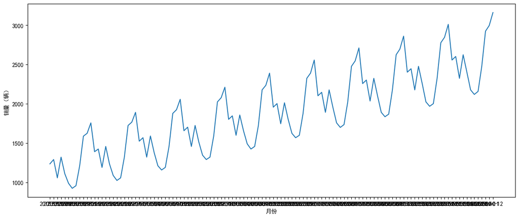

```python
plt.rcParams["figure.figsize"]= [15,6]
sns.lineplot(x=data["月份"], y=data['销量（辆）'])
```

有上述结果解释:整体上看2015-1到2024-12的销量呈整体上涨的趋势。

用图表显示,平均油价,有无促销,政策补贴,季节这四个特征与销量的变化

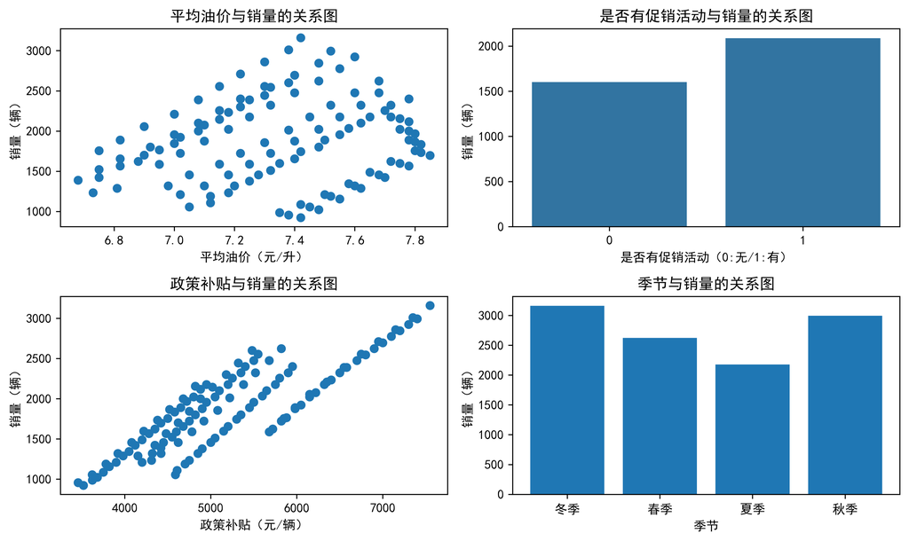

```python
plt.rcParams["figure.figsize"]= [13.00,6]
plt.rcParams['figure.autolayout'] = True
fig,((ax1,ax2),(ax3,ax4)) = plt.subplots(2,2, figsize = (10,6),dpi=600)

ax1.scatter(data["平均油价（元/升）"], data['销量（辆）'])
ax1.set_xlabel("平均油价（元/升）"); ax1.set_ylabel('销量（辆）'); ax1.set_title('平均油价与销量的关系图')

sns.barplot(x=data["是否有促销活动（0/1）"], y=data['销量（辆）'], ax=ax2,ci=None)
ax2.set_xlabel("是否有促销活动（0:无/1:有）")
ax2.set_ylabel('销量（辆）')
ax2.set_title('是否有促销活动与销量的关系图')


ax3.scatter(data["政策补贴（元/辆）"], data['销量（辆）'])
ax3.set_xlabel("政策补贴（元/辆）"); ax3.set_ylabel('销量（辆）'); ax3.set_title('政策补贴与销量的关系图')

ax4.bar(data["季节"], data['销量（辆）'])
ax4.set_xlabel("季节"); ax4.set_ylabel('销量（辆）'); ax4.set_title('季节与销量的关系图')
```

```python
data[['年', '月']] = data['月份'].str.split('-', expand=True)
data['年'] = data['年'].astype(int)
data['月'] = data['月'].astype(int)


data = data.drop('月份', axis=1)
```

```python
data = pd.get_dummies(data,drop_first= True, columns = [ '是否有促销活动（0/1）','季节'
                                                         ], dtype=int)
data
```

|  | 平均油价（元/升） | 政策补贴（元/辆） | 销量（辆） | 年 | 月 | 是否有促销活动（0/1）_1 | 季节_夏季 | 季节_春季 | 季节_秋季 |
| --- | --- | --- | --- | --- | --- | --- | --- | --- | --- |
| 0 | 6.73 | 4310 | 1234 | 2015 | 1 | 1 | 0 | 0 | 0 |
| 1 | 6.81 | 4152 | 1289 | 2015 | 2 | 1 | 0 | 0 | 0 |
| 2 | 7.05 | 4589 | 1056 | 2015 | 3 | 0 | 0 | 1 | 0 |
| 3 | 6.98 | 4421 | 1320 | 2015 | 4 | 1 | 0 | 1 | 0 |
| 4 | 7.12 | 4608 | 1109 | 2015 | 5 | 0 | 0 | 1 | 0 |
| ... | ... | ... | ... | ... | ... | ... | ... | ... | ... |
| 115 | 7.75 | 4820 | 2156 | 2024 | 8 | 0 | 1 | 0 | 0 |
| 116 | 7.68 | 5500 | 2476 | 2024 | 9 | 1 | 0 | 0 | 1 |
| 117 | 7.60 | 7300 | 2923 | 2024 | 10 | 1 | 0 | 0 | 1 |
| 118 | 7.52 | 7400 | 2995 | 2024 | 11 | 1 | 0 | 0 | 1 |
| 119 | 7.42 | 7550 | 3160 | 2024 | 12 | 1 | 0 | 0 | 0 |

120 rows × 9 columns

```python
y=data["销量（辆）"]
X = data.drop("销量（辆）",axis=1)
```

```
<function matplotlib.pyplot.show(close=None, block=None)>
```

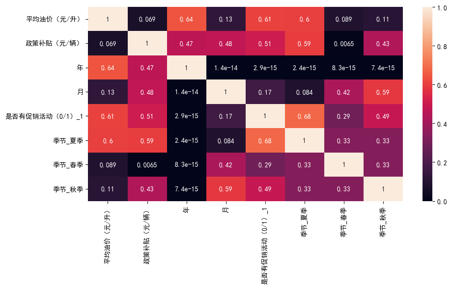

```python
plt.rcParams["figure.figsize"]= [10,6]
plt.rcParams['figure.autolayout'] = True
sns.heatmap(X.corr().abs(),annot=True)
plt.show
```

```python
X = sm.add_constant(X)
```

```python
model = sm.OLS(y,X).fit()
model.summary()
```

OLS Regression Results

| Dep. Variable: | 销量（辆） | R-squared: | 0.998 |
| --- | --- | --- | --- |
| Model: | OLS | Adj. R-squared: | 0.997 |
| Method: | Least Squares | F-statistic: | 5600. |
| Date: | Tue, 03 Feb 2026 | Prob (F-statistic): | 6.41e-141 |
| Time: | 16:51:08 | Log-Likelihood: | -559.00 |
| No. Observations: | 120 | AIC: | 1136. |
| Df Residuals: | 111 | BIC: | 1161. |
| Df Model: | 8 |  |  |
| Covariance Type: | nonrobust |  |  |

|  | coef | std err | t | P>\|t\| | [0.025 | 0.975] |
| --- | --- | --- | --- | --- | --- | --- |
| const | -1.912e+05 | 7268.043 | -26.308 | 0.000 | -2.06e+05 | -1.77e+05 |
| 平均油价（元/升） | 98.1931 | 43.699 | 2.247 | 0.027 | 11.601 | 184.785 |
| 政策补贴（元/辆） | 0.2733 | 0.008 | 35.665 | 0.000 | 0.258 | 0.288 |
| 年 | 94.4799 | 3.753 | 25.172 | 0.000 | 87.042 | 101.918 |
| 月 | 5.8074 | 1.817 | 3.196 | 0.002 | 2.206 | 9.408 |
| 是否有促销活动（0/1）_1 | 283.3356 | 11.016 | 25.720 | 0.000 | 261.507 | 305.165 |
| 季节_夏季 | -8.3513 | 23.887 | -0.350 | 0.727 | -55.684 | 38.982 |
| 季节_春季 | -73.7265 | 16.140 | -4.568 | 0.000 | -105.709 | -41.744 |
| 季节_秋季 | -149.5107 | 11.614 | -12.874 | 0.000 | -172.524 | -126.498 |

| Omnibus: | 3.705 | Durbin-Watson: | 1.986 |
| --- | --- | --- | --- |
| Prob(Omnibus): | 0.157 | Jarque-Bera (JB): | 3.128 |
| Skew: | 0.321 | Prob(JB): | 0.209 |
| Kurtosis: | 3.463 | Cond. No. | 1.70e+07 |

Notes:  
[1] Standard Errors assume that the covariance matrix of the errors is correctly specified.  
[2] The condition number is large, 1.7e+07. This might indicate that there are  
strong multicollinearity or other numerical problems.

有上述结果解释:

一、 模型表现解释力极强,R-squared = 0.998,能解释99%的销量变动。

```python
predict_data = pd.read_csv("汽车模拟数据特征集.csv")

predict_data.info()
```

```
<class 'pandas.core.frame.DataFrame'>
RangeIndex: 12 entries, 0 to 11
Data columns (total 6 columns):
 #   Column        Non-Null Count  Dtype
---  ------        --------------  -----
 0   年             12 non-null     int64
 1   月             12 non-null     int64
 2   平均油价（元/升）     12 non-null     float64
 3   政策补贴（元/辆）     12 non-null     int64
 4   是否有促销活动（0/1）  12 non-null     int64
 5   季节            12 non-null     object
dtypes: float64(1), int64(4), object(1)
memory usage: 704.0+ bytes
```

```python
predict_data = pd.get_dummies(predict_data,drop_first=True,columns=["是否有促销活动（0/1）"	,"季节"], dtype=int)
```

```python
predict_data = sm.add_constant(predict_data, has_constant='add', prepend=True)


predict_data
```

|  | const | 年 | 月 | 平均油价（元/升） | 政策补贴（元/辆） | 是否有促销活动（0/1）_1 | 季节_夏季 | 季节_春季 | 季节_秋季 |
| --- | --- | --- | --- | --- | --- | --- | --- | --- | --- |
| 0 | 1.0 | 2025 | 1 | 7.35 | 5700 | 1 | 0 | 0 | 0 |
| 1 | 1.0 | 2025 | 2 | 7.42 | 5630 | 1 | 0 | 0 | 0 |
| 2 | 1.0 | 2025 | 3 | 7.78 | 6050 | 0 | 0 | 1 | 0 |
| 3 | 1.0 | 2025 | 4 | 7.73 | 5980 | 1 | 0 | 1 | 0 |
| 4 | 1.0 | 2025 | 5 | 7.83 | 6100 | 0 | 0 | 1 | 0 |
| 5 | 1.0 | 2025 | 6 | 7.78 | 5100 | 0 | 1 | 0 | 0 |
| 6 | 1.0 | 2025 | 7 | 7.85 | 5030 | 0 | 1 | 0 | 0 |
| 7 | 1.0 | 2025 | 8 | 7.82 | 4980 | 0 | 1 | 0 | 0 |
| 8 | 1.0 | 2025 | 9 | 7.73 | 5650 | 1 | 0 | 0 | 1 |
| 9 | 1.0 | 2025 | 10 | 7.65 | 7600 | 1 | 0 | 0 | 1 |
| 10 | 1.0 | 2025 | 11 | 7.58 | 7700 | 1 | 0 | 0 | 1 |
| 11 | 1.0 | 2025 | 12 | 7.48 | 7850 | 1 | 0 | 0 | 0 |

```python
model.params
```

```
const            -191205.447081
平均油价（元/升）             98.193072
政策补贴（元/辆）              0.273266
年                     94.479946
月                      5.807430
是否有促销活动（0/1）_1       283.335594
季节_夏季                 -8.351310
季节_春季                -73.726479
季节_秋季               -149.510657
dtype: float64
```

```python
predicted_value = model.predict(predict_data)
```